# Wind processing with tidyverse - R Notebook

## Esperienza 1 - Laboratorio di Fisica dell’Atmosfera A.A. 2022/23

**Autore**: Giacomo Roversi

Per cominciare inizializziamo l’ambiente di calcolo: cancello eventuali variabili e carico i pacchetti necessari.

```r
# clear the workspace
rm(list=ls())
```

```r
# load packages
require(tidyverse)
require(lubridate)
require(zoo)
```

### Definizione dei nomi dei files e delle cartelle

Genero tutti i nomi dei vari output del progetto partendo dalla variabile “radice” che imposto qui. L’ho chiamata `StationDataRootName`. Dichiaro tutto all’inizio del codice per non dover andare poi in cerca dei nomi se volessi fare delle modifiche. Distribuisco i files in tre cartelle: `datafolder` conterrà solo i dati grezzi in input, da non modificare, `resfolder` conterrà tutti i dati processati e i risultati, `figfolder` le figure.

```r
# Define the project directories (relative path)
datafolder <- "Esp_1/dati/"
figfolder  <- "Esp_1/figure/"
resfolder  <- "Esp_1/risultati/"

# Create the project directories, if missing
if(!dir.exists(datafolder)){ dir.create(datafolder) }
if(!dir.exists(figfolder)){  dir.create(figfolder) }
if(!dir.exists(resfolder)){  dir.create(resfolder) }

# Define the input filenames and assign them to a variable
StationDataRootName <- "Dati Meteo - Stazione A"

filenames <- list(
  input           = paste0(datafolder, StationDataRootName, ".txt"),

  output.proc     = paste0(resfolder , StationDataRootName, "_proc.txt"),
  output.ExcTIME  = paste0(resfolder , StationDataRootName, "_ExcTIME.txt"),
  output.ExcWSneg = paste0(resfolder , StationDataRootName, "_ExcWSneg.txt"),
  ouput.ExcWS3h   = paste0(resfolder , StationDataRootName, "_ExcWS3h.txt"),
  output.LAKES    = paste0(resfolder , StationDataRootName, "_LAKES.txt"),

  figure.DataConsistency = paste0(figfolder, StationDataRootName, "_DataConsistency.png"),
  figure.HistWS          = paste0(figfolder, StationDataRootName, "_HistWS.png"),
  figure.WindRose        = paste0(figfolder, StationDataRootName, "_WindRose.png"),
  figure.ScatterPlot     = paste0(figfolder, StationDataRootName, "_ScatterPlot.png"),
  figure.DailyWind       = paste0(figfolder, StationDataRootName, "_DailyWind.png")
)
```

### Correzione dell’intestazione dei files di dati delle stazioni Davis

Leggo la prima riga e la spezzo dove ci sono le virgole, poi processo il risultato attraverso vari passaggi di sostituzione caratteri in modo da eliminare il cancelletto a inizio riga e i vari spazi vuoti rimasti. Salvo il tutto nella variabile “header”, che mi servirà tra poco.

```r
connection <- file(filenames$input)
open(connection)

header <- strsplit(readLines(connection, 1), ",")[[1]] %>%
  str_replace("#", "")     %>%
  str_replace("     ", "") %>%
  str_replace("    ", "")  %>%
  str_replace("   ", "")   %>%
  str_replace(" ", "")     %>%
  str_replace(" ", "")

close(connection)
```

**Nota 1.** L’operatore `%>%` concatena l’output di una funzione come input della successiva (come l’operatore “pipe” `|` in bash ad esempio) . Solo le funzioni del pacchetto `tidyverse` sono predisposte per accettare questa concatenazione in input. Le funzioni base di R invece sono utilizzate nella prima riga nella classica forma innestata (“nested”), ovvero una dentro l’altra.

**Nota 2.** La funzione `strsplit()` restituisce come output una **lista** (vedi `?list`). La lista ha un solo elemento, costituito da un vettore di stringhe di caratteri, che sarebbero i vari pezzi in cui è stata suddivisa la prima riga del nostro file di input. Il suffisso `[[1]]` che compare dopo `strsplit()` serve a selezionare direttamente il vettore caratteri contenuto nella prima posizione della lista, invece che tutta la lista, che non sarebbe un input corretto per `str_replace()`.

### Lettura intelligente del file dei dati

Tramite il pacchetto `readr` (incluso in `tidyerse`), le colonne “Date” e “Time” possono essere già importate rispettivamente come date e orari (formati specifici). In questo modo facilitiamo le operazioni sugli intervalli temporali (i giorni del calendario e le ore del giorno vengono gestite in automatico).

Il metodo di definizione dei nomi delle variabili (colonne) è robusto perché ho preso i nomi direttamente dal file originale (variabile `header` assegnata a `col_names`), quindi non rischio di sbagliare l’ordine definendole manualmente. Se nel file di input cambiassero ad esempio l’ordine o il numero delle colonne, la nostra tabella si adeguerebbe in automatico (nel limite che il file non cambi così tanto da invalidare le convenzioni alla base della correzione al punto precedente).

```r
# READING DATA
StationData <- read_table(filenames$input,
                            col_types = list(
                              Date = col_datetime(format = "%Y%m%d"),
                              Time = col_time(format = "%H.%M")
                            ),
                          comment = "#",
                          col_names = header)
print(StationData) #%>% head()
```

| Date | Time | Interval | Press | inTemp | outTemp | inHum | outHum | wndSpeed | wndDir | windGust | wGstDir | rainRate | rain | dewpoint | wdChill | heatIndx | ET | totRad | UV |
| --- | --- | --- | --- | --- | --- | --- | --- | --- | --- | --- | --- | --- | --- | --- | --- | --- | --- | --- | --- |
| 2005-09-22 | 03:00:00 | 30 | 1017.27 | 22.22 | 14.28 | 44 | 76 | 0.447 | 270.0 | 2.235 | 292.5 | 0.00 | 0.00 | 10.10 | 14.28 | 14.28 | 0.00 | 0 | 0.8 |
| 2005-09-22 | 03:30:00 | 30 | 1017.21 | 22.11 | 14.11 | 45 | 76 | 0.447 | 270.0 | 3.129 | 270.0 | 0.00 | 0.00 | 9.94 | 14.11 | 14.11 | 0.00 | 0 | 0.8 |
| 2005-09-22 | 05:00:00 | 30 | 1017.17 | 21.83 | 13.89 | 45 | 76 | 0.447 | 292.5 | 2.235 | 315.0 | 0.00 | 0.00 | 9.73 | 13.89 | 13.89 | 0.00 | 0 | 0.8 |
| 2005-09-22 | 05:30:00 | 30 | 1017.24 | 21.72 | 13.78 | 46 | 76 | 0.447 | 270.0 | 2.682 | 315.0 | 0.00 | 0.00 | 9.62 | 13.78 | 13.78 | 0.00 | 0 | 0.8 |
| 2005-09-22 | 04:00:00 | 30 | 1017.31 | 22.06 | 13.94 | 45 | 76 | 0.447 | 270.0 | 2.682 | 270.0 | 0.00 | 0.00 | 9.78 | 13.94 | 13.94 | 0.00 | 0 | 0.8 |
| 2005-09-22 | 04:30:00 | 30 | 1017.27 | 21.94 | 13.94 | 45 | 76 | 0.000 | 270.0 | 1.788 | 270.0 | 0.00 | 0.00 | 9.78 | 13.94 | 13.94 | 0.00 | 0 | 0.8 |
| 2005-09-22 | 06:00:00 | 30 | 1017.24 | 21.67 | 13.78 | 46 | 78 | 0.447 | 270.0 | 3.576 | 270.0 | 0.00 | 0.00 | 10.01 | 13.78 | 13.78 | 0.00 | 0 | 0.8 |
| 2005-09-22 | 06:30:00 | 30 | 1017.31 | 21.56 | 13.89 | 46 | 77 | 0.894 | 270.0 | 3.576 | 270.0 | 0.00 | 0.00 | 9.92 | 13.89 | 13.89 | 0.00 | 0 | 0.8 |
| 2005-09-22 | 07:00:00 | 30 | 1017.41 | 21.44 | 14.11 | 46 | 77 | 0.447 | 270.0 | 2.682 | 247.5 | 0.00 | 0.00 | 10.14 | 14.11 | 14.11 | 0.00 | 0 | 0.8 |
| 2005-09-22 | 07:30:00 | 30 | 1017.51 | 21.44 | 14.39 | 46 | 76 | 0.447 | 270.0 | 2.682 | 247.5 | 0.00 | 0.00 | 10.21 | 14.39 | 14.39 | 0.00 | 16 | 0.8 |

[output cut: 990 more lines]

I dati vengono salvati direttamente in una “*tibble*”, che è un “*data.frame*” - ma potenziato - che costituisce la struttura dati di base del pacchetto `tidyr` di `tidyverse`. L’output nel terminale è già tagliato in modo da non occupare troppe righe e sono incluse informazioni sui formati delle varie colonne. La visualizzazione è interattiva e permettere di scorrere verso destra per vedere le colonne oltre la decima.

### Variabili aggiuntive di supporto

Aggiungo colonne di supporto, non deve preoccuparmi la ridondanza, la memoria viene comunque gestita in modo efficiente a questo livello. Unisco data e ora nella colonna “DateTime”.

```r
StationData$DateTime <- StationData$Date + StationData$Time
head(StationData[,c("Date", "Time", "DateTime", "Interval", "Press")])
```

| Date | Time | DateTime | Interval | Press |
| --- | --- | --- | --- | --- |
| 2005-09-22 | 03:00:00 | 2005-09-22 03:00:00 | 30 | 1017.27 |
| 2005-09-22 | 03:30:00 | 2005-09-22 03:30:00 | 30 | 1017.21 |
| 2005-09-22 | 05:00:00 | 2005-09-22 05:00:00 | 30 | 1017.17 |
| 2005-09-22 | 05:30:00 | 2005-09-22 05:30:00 | 30 | 1017.24 |
| 2005-09-22 | 04:00:00 | 2005-09-22 04:00:00 | 30 | 1017.31 |
| 2005-09-22 | 04:30:00 | 2005-09-22 04:30:00 | 30 | 1017.27 |

Poi creo una colonna di “factors” per la divisione in stagioni meteorologiche. I factor sono un formato di variabili in R, sono delle etichette predisposte per acquisire solo valori preimpostati, detti “livelli” (vedi `?factor`).

```r
# creo un vettore caratteri vuoto, della dimensione delle righe di StationData
Season <- character(length = length(StationData$DateTime))

Season[which(month(StationData$DateTime) %in% c(12, 1:2))] <- "DJF"
Season[which(month(StationData$DateTime) %in% 3:5)]        <- "MAM"
Season[which(month(StationData$DateTime) %in% 6:8)]        <- "JJA"
Season[which(month(StationData$DateTime) %in% 9:11)]       <- "SON"

StationData$Season <- factor(Season, levels = c("DJF", "MAM", "JJA", "SON"))
```

**Attenzione!**

1. Le misure non sono ordinate temporalmente. Uso la nuova colonna per riordinarle:

```r
StationData <- StationData[order(StationData$"DateTime"),]
head(StationData[,c("Date", "Time", "DateTime", "Interval", "Press")])
```

| Date | Time | DateTime | Interval | Press |
| --- | --- | --- | --- | --- |
| 2005-09-22 | 03:00:00 | 2005-09-22 03:00:00 | 30 | 1017.27 |
| 2005-09-22 | 03:30:00 | 2005-09-22 03:30:00 | 30 | 1017.21 |
| 2005-09-22 | 04:00:00 | 2005-09-22 04:00:00 | 30 | 1017.31 |
| 2005-09-22 | 04:30:00 | 2005-09-22 04:30:00 | 30 | 1017.27 |
| 2005-09-22 | 05:00:00 | 2005-09-22 05:00:00 | 30 | 1017.17 |
| 2005-09-22 | 05:30:00 | 2005-09-22 05:30:00 | 30 | 1017.24 |

```r
NA
```

2. Nel dataset convivono misure a diversi intervalli temporali. Lo vedo cercando i diversi valori che acquisisce la variabile “Interval”:

```r
unique(StationData$Interval)
```

```
[1] 30  1  5 10
```

```r
StationData[which(StationData$Interval == 1),]
```

| Date | Time | Interval | Press | inTemp | outTemp | inHum | outHum | wndSpeed | wndDir | windGust | wGstDir | rainRate | rain | dewpoint | wdChill | heatIndx | ET | totRad | UV | DateTime | Season |
| --- | --- | --- | --- | --- | --- | --- | --- | --- | --- | --- | --- | --- | --- | --- | --- | --- | --- | --- | --- | --- | --- |
| 2005-11-28 | 11:20:00 | 1 | 1003.93 | 21.39 | 8.50 | 37 | 55.0 | 0.894 | 0.0 | 1.341 | 0.0 | 0.0 | 0.0 | -0.02 | 8.50 | 8.50 | 0.00 | 299.0 | -99.9 | 2005-11-28 11:20:00 | SON |
| 2005-11-28 | 11:21:00 | 1 | 1003.93 | 21.39 | 8.50 | 37 | 56.0 | 0.000 | 0.0 | 0.894 | 0.0 | 0.0 | 0.0 | 0.23 | 8.50 | 8.50 | 0.00 | 301.0 | 1.5 | 2005-11-28 11:21:00 | SON |
| 2005-11-28 | 11:22:00 | 1 | 1003.93 | 21.39 | 8.50 | 36 | 56.0 | 0.447 | 0.0 | 1.341 | 337.5 | 0.0 | 0.0 | 0.23 | 8.50 | 8.50 | 0.00 | 301.0 | 1.5 | 2005-11-28 11:22:00 | SON |
| 2005-11-28 | 12:26:00 | 1 | 1003.76 | 21.89 | 7.11 | 34 | 61.0 | 0.000 | 22.5 | 0.894 | 22.5 | 0.0 | 0.0 | 0.10 | 7.11 | 7.11 | 0.00 | 294.0 | 1.5 | 2005-11-28 12:26:00 | SON |
| 2005-11-28 | 12:27:00 | 1 | 1003.76 | 21.89 | 7.22 | 34 | 61.0 | 0.000 | 22.5 | 0.447 | 22.5 | 0.0 | 0.0 | 0.21 | 7.22 | 7.22 | 0.00 | 294.0 | 1.5 | 2005-11-28 12:27:00 | SON |
| 2005-11-28 | 12:28:00 | 1 | 1003.76 | 22.00 | 7.28 | 34 | 61.0 | 0.447 | 0.0 | 1.341 | 0.0 | 0.0 | 0.0 | 0.26 | 7.28 | 7.28 | 0.00 | 296.0 | 1.5 | 2005-11-28 12:28:00 | SON |
| 2005-11-28 | 12:29:00 | 1 | 1003.76 | 22.00 | 7.28 | 34 | 61.0 | 0.000 | -99.9 | 0.000 | -99.9 | 0.0 | 0.0 | 0.26 | 7.28 | 7.28 | 0.00 | 296.0 | 1.5 | 2005-11-28 12:29:00 | SON |
| 2005-11-28 | 12:30:00 | 1 | 1003.90 | 22.00 | 7.39 | 34 | 61.0 | 0.000 | 0.0 | 0.447 | 0.0 | 0.0 | 0.0 | 0.36 | 7.39 | 7.39 | 0.00 | 293.0 | 1.5 | 2005-11-28 12:30:00 | SON |
| 2005-11-28 | 12:31:00 | 1 | 1003.90 | 22.06 | 7.28 | 34 | 61.0 | 0.000 | 0.0 | 0.894 | 22.5 | 0.0 | 0.0 | 0.26 | 7.28 | 7.28 | 0.00 | 294.0 | 1.5 | 2005-11-28 12:31:00 | SON |
| 2005-11-28 | 12:32:00 | 1 | 1003.90 | 22.06 | 7.28 | 34 | 61.0 | 0.000 | 22.5 | 0.894 | 22.5 | 0.0 | 0.0 | 0.26 | 7.28 | 7.28 | 0.00 | 294.0 | 1.5 | 2005-11-28 12:32:00 | SON |

[output cut: 990 more lines]

### Grafici esplorativi

Come si distribuiscono le diverse risoluzioni temporali?

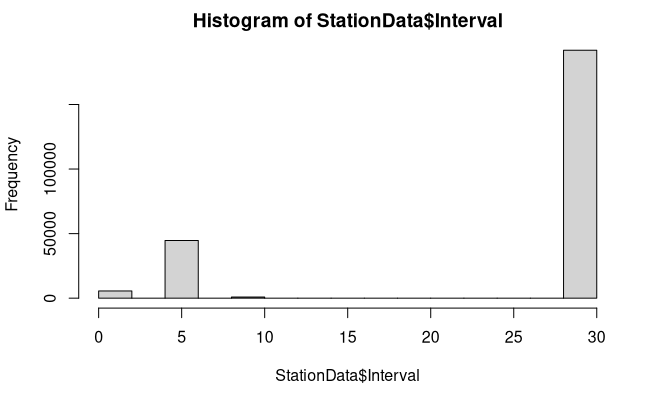

```r
# istogramma con le funzioni base di R
hist(StationData$Interval)
```

Quando abbiamo dati al minuto?

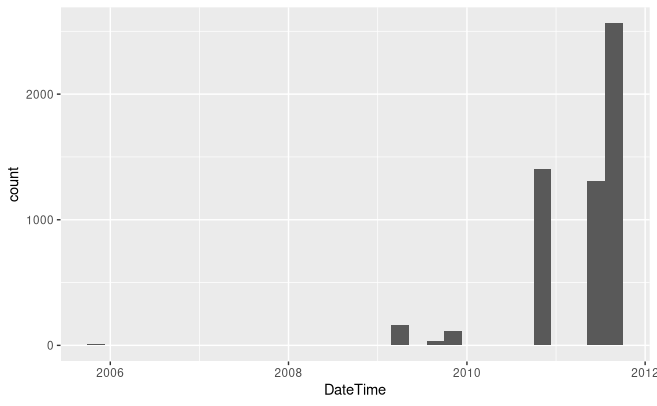

```r
# istogramma con le funzioni ggplot della suite tidyverse
StationData %>%
  filter(
    Interval == 1
  ) %>%
  ggplot(aes(DateTime)) +
  geom_histogram(bins = 30)
```

La funzione `geom_histogram()` crea un istogramma della variabile specificata in `aes()`. Il parametro aggiuntivo fill dentro `aes()` permettere di suddividere le colonne dell’istogramma per stagione, andando a differenziare il colore di riempimento (“fill” appunto).

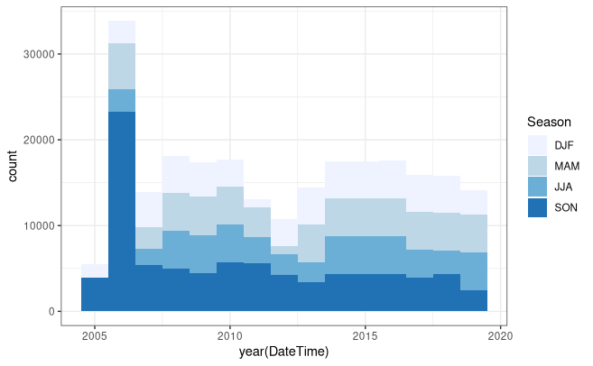

```r
StationData %>%
  ggplot(aes(year(DateTime), fill = Season)) +
  geom_histogram(binwidth = 1) +
  scale_fill_brewer() +
  theme_bw()
```

La funzione `geom_count()` è utile per scatterplots e simili, dove c’è rischio concreto di overplotting.

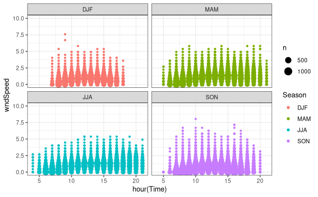

```r
# Un esempio di grafico con la suite ggplot2 preceduta da un filtro
StationData %>%
  filter(
    Press > 800,
    outTemp > -30,
    outHum > 0,
    totRad > 0
  ) %>%
ggplot(aes(hour(Time), wndSpeed, color = Season)) +
  geom_count() +
  # geom_point() +                    # issue: overplotting
  # geom_boxplot() +                  # dovrei cambiare la variabile in x
  facet_wrap(~Season) +               # divido in quattro box
  coord_cartesian(ylim = c(0, 10)) +  # taglio alcuni valori estremi
  theme_bw()
```

```r
# si potrebbero cambiare i colori e l'ordine delle stagioni!
```

Lo stesso grafico, usando però `geom_point()` che è affetto da overplotting. Non si capisce quali punti siano più popolati e il rendering della figura è molto rallentato (vengono disegnati inutilmente tantissimi punti).

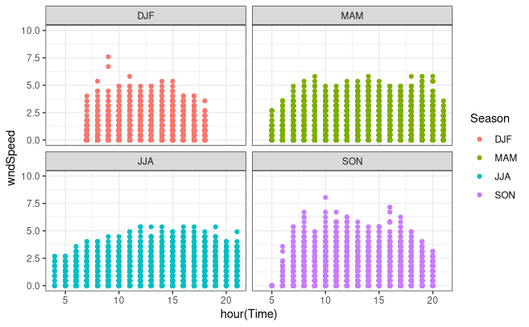

```r
StationData %>%
  filter(
    Press > 800,
    outTemp > -30,
    outHum > 0,
    totRad > 0
  ) %>%
ggplot(aes(hour(Time), wndSpeed, color = Season)) +
  geom_point() +                    # issue: overplotting
  # geom_boxplot() +                  # dovrei cambiare la variabile in x
  facet_wrap(~Season) +               # divido in quattro box
  coord_cartesian(ylim = c(0, 10)) +  # taglio alcuni valori estremi
  theme_bw()
```

Scatterplot che mette tre variabili a confronto…

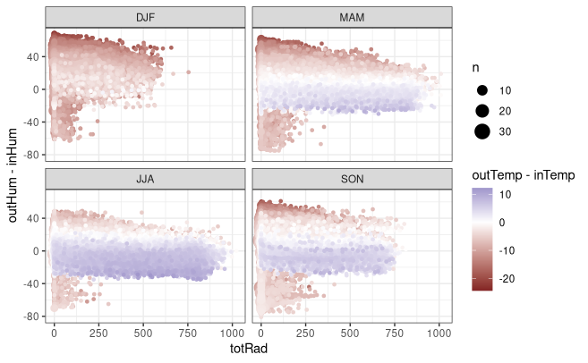

```r
StationData %>%
  filter(
    wndSpeed >= 0,
    outHum >=0,
    outTemp > -50,
    inTemp > 0,
    totRad >=0
    ) %>%
  ggplot(aes(totRad, outHum-inHum, color = outTemp-inTemp)) +
  geom_count() +
  facet_wrap(~Season) +
  scale_color_gradient2() +
  # coord_cartesian(xlim = c(0,100)) +
  # coord_fixed(
  #   xlim=c(0,20),
  #   ylim=c(0,20)
  #   ) +
  theme_bw()
```

### Filtri

Tramite la funzione `filter()` del pacchetto `dplyr` (sempre di tidyverse) posso creare filtri ponendo condizioni direttamente sulle colonne del dataset originale.

Tramite la funzione `minute()` del pacchetto `lubridate()` seleziono solo le righe prese allo scadere dell’ora.

Salvo un sottoinsieme del dataset in una nuova variabile, raccogliendo solo i dati orari. Attenzione perché la variabile “Interval” rimane impostata sulla risoluzione temporale originaria. Voglio solo misure orarie provenienti dalle letture ogni 30 minuti quindi richiedo anche che Interval == 30.

```r
HourlyData <- StationData %>%
  filter(
    minute(DateTime) == 0,
    Interval == 30
  )

print(HourlyData)
```

| Date | Time | Interval | Press | inTemp | outTemp | inHum | outHum | wndSpeed | wndDir | windGust | wGstDir | rainRate | rain | dewpoint | wdChill | heatIndx | ET | totRad | UV | DateTime | Season |
| --- | --- | --- | --- | --- | --- | --- | --- | --- | --- | --- | --- | --- | --- | --- | --- | --- | --- | --- | --- | --- | --- |
| 2005-09-22 | 03:00:00 | 30 | 1017.27 | 22.22 | 14.28 | 44 | 76 | 0.447 | 270.0 | 2.235 | 292.5 | 0.00 | 0.00 | 10.10 | 14.28 | 14.28 | 0.00 | 0 | 0.8 | 2005-09-22 03:00:00 | SON |
| 2005-09-22 | 04:00:00 | 30 | 1017.31 | 22.06 | 13.94 | 45 | 76 | 0.447 | 270.0 | 2.682 | 270.0 | 0.00 | 0.00 | 9.78 | 13.94 | 13.94 | 0.00 | 0 | 0.8 | 2005-09-22 04:00:00 | SON |
| 2005-09-22 | 05:00:00 | 30 | 1017.17 | 21.83 | 13.89 | 45 | 76 | 0.447 | 292.5 | 2.235 | 315.0 | 0.00 | 0.00 | 9.73 | 13.89 | 13.89 | 0.00 | 0 | 0.8 | 2005-09-22 05:00:00 | SON |
| 2005-09-22 | 06:00:00 | 30 | 1017.24 | 21.67 | 13.78 | 46 | 78 | 0.447 | 270.0 | 3.576 | 270.0 | 0.00 | 0.00 | 10.01 | 13.78 | 13.78 | 0.00 | 0 | 0.8 | 2005-09-22 06:00:00 | SON |
| 2005-09-22 | 07:00:00 | 30 | 1017.41 | 21.44 | 14.11 | 46 | 77 | 0.447 | 270.0 | 2.682 | 247.5 | 0.00 | 0.00 | 10.14 | 14.11 | 14.11 | 0.00 | 0 | 0.8 | 2005-09-22 07:00:00 | SON |
| 2005-09-22 | 08:00:00 | 30 | 1017.75 | 21.44 | 14.22 | 46 | 76 | 0.447 | 292.5 | 2.682 | 292.5 | 0.00 | 0.00 | 10.05 | 14.22 | 14.22 | 0.03 | 37 | 0.9 | 2005-09-22 08:00:00 | SON |
| 2005-09-22 | 09:00:00 | 30 | 1018.02 | 21.44 | 14.72 | 47 | 76 | 0.894 | 292.5 | 3.576 | 292.5 | 0.00 | 0.00 | 10.53 | 14.72 | 14.72 | 0.08 | 142 | 1.3 | 2005-09-22 09:00:00 | SON |
| 2005-09-22 | 10:00:00 | 30 | 1018.39 | 21.67 | 15.50 | 46 | 74 | 0.894 | 337.5 | 4.470 | 337.5 | 0.00 | 0.00 | 10.88 | 15.50 | 15.50 | 0.08 | 144 | 1.8 | 2005-09-22 10:00:00 | SON |
| 2005-09-22 | 11:00:00 | 30 | 1018.39 | 22.33 | 17.78 | 47 | 68 | 0.894 | 270.0 | 3.129 | 270.0 | 0.00 | 0.00 | 11.79 | 17.78 | 17.78 | 0.20 | 534 | 3.1 | 2005-09-22 11:00:00 | SON |
| 2005-09-22 | 12:00:00 | 30 | 1018.39 | 23.06 | 18.50 | 51 | 68 | 1.341 | 270.0 | 4.917 | 270.0 | 0.00 | 0.00 | 12.48 | 18.50 | 18.50 | 0.28 | 551 | 4.1 | 2005-09-22 12:00:00 | SON |

[output cut: 990 more lines]

Per salvare il dataset di tutte le righe escluse posso usare nuovamente filter stando attento di impostare i filtri in modo complementare, oppure posso usare la funzione `setdiff()` di `dplyr`. Dichiaro l’appartenenza al pacchetto in modo esplicito per essere sicuro che non ci siano ambiguità nel caso di più funzioni con lo stesso nome.

```r
excludedData <- dplyr::setdiff(StationData, HourlyData)
print(excludedData)
```

| Date | Time | Interval | Press | inTemp | outTemp | inHum | outHum | wndSpeed | wndDir | windGust | wGstDir | rainRate | rain | dewpoint | wdChill | heatIndx | ET | totRad | UV | DateTime | Season |
| --- | --- | --- | --- | --- | --- | --- | --- | --- | --- | --- | --- | --- | --- | --- | --- | --- | --- | --- | --- | --- | --- |
| 2005-09-22 | 03:30:00 | 30 | 1017.21 | 22.11 | 14.11 | 45 | 76 | 0.447 | 270.0 | 3.129 | 270.0 | 0.00 | 0.00 | 9.94 | 14.11 | 14.11 | 0 | 0 | 0.8 | 2005-09-22 03:30:00 | SON |
| 2005-09-22 | 04:30:00 | 30 | 1017.27 | 21.94 | 13.94 | 45 | 76 | 0.000 | 270.0 | 1.788 | 270.0 | 0.00 | 0.00 | 9.78 | 13.94 | 13.94 | 0 | 0 | 0.8 | 2005-09-22 04:30:00 | SON |
| 2005-09-22 | 05:30:00 | 30 | 1017.24 | 21.72 | 13.78 | 46 | 76 | 0.447 | 270.0 | 2.682 | 315.0 | 0.00 | 0.00 | 9.62 | 13.78 | 13.78 | 0 | 0 | 0.8 | 2005-09-22 05:30:00 | SON |
| 2005-09-22 | 06:30:00 | 30 | 1017.31 | 21.56 | 13.89 | 46 | 77 | 0.894 | 270.0 | 3.576 | 270.0 | 0.00 | 0.00 | 9.92 | 13.89 | 13.89 | 0 | 0 | 0.8 | 2005-09-22 06:30:00 | SON |
| 2005-09-22 | 07:30:00 | 30 | 1017.51 | 21.44 | 14.39 | 46 | 76 | 0.447 | 270.0 | 2.682 | 247.5 | 0.00 | 0.00 | 10.21 | 14.39 | 14.39 | 0 | 16 | 0.8 | 2005-09-22 07:30:00 | SON |
| 2005-09-22 | 08:30:00 | 30 | 1017.82 | 21.44 | 14.50 | 46 | 75 | 0.447 | 292.5 | 3.129 | 270.0 | 0.00 | 0.00 | 10.12 | 14.50 | 14.50 | 0 | 111 | 1.1 | 2005-09-22 08:30:00 | SON |
| 2005-09-22 | 09:30:00 | 30 | 1018.29 | 21.39 | 15.06 | 47 | 75 | 0.894 | 315.0 | 3.576 | 315.0 | 0.00 | 0.00 | 10.66 | 15.06 | 15.06 | 0 | 97 | 1.5 | 2005-09-22 09:30:00 | SON |
| 2005-09-22 | 10:30:00 | 30 | 1018.46 | 21.83 | 16.44 | 47 | 73 | 0.894 | 337.5 | 4.470 | 337.5 | 0.00 | 0.00 | 11.59 | 16.44 | 16.44 | 0 | 236 | 2.2 | 2005-09-22 10:30:00 | SON |
| 2005-09-22 | 11:30:00 | 30 | 1018.39 | 22.78 | 18.00 | 49 | 68 | 0.894 | 270.0 | 4.470 | 270.0 | 0.00 | 0.00 | 12.00 | 18.00 | 18.00 | 0 | 353 | 3.2 | 2005-09-22 11:30:00 | SON |
| 2005-09-22 | 12:30:00 | 30 | 1018.32 | 23.17 | 19.11 | 50 | 65 | 1.788 | 337.5 | 5.364 | 270.0 | 0.00 | 0.00 | 12.37 | 19.11 | 19.11 | 0 | 591 | 4.4 | 2005-09-22 12:30:00 | SON |

[output cut: 990 more lines]

Filtro i valori non verosimili della velocità del vento.

```r
windData <- StationData %>%
  filter(
    Interval == 30, # seleziono solo misure a 30 minuti

    wndSpeed >= 0,
    wndSpeed <= 25,

    wndDir >= 0,
    wndDir <= 360

  )%>%
  select(DateTime, wndDir, wndSpeed)

print(windData)
```

| DateTime | wndDir | wndSpeed |
| --- | --- | --- |
| 2005-09-22 03:00:00 | 270.0 | 0.447 |
| 2005-09-22 03:30:00 | 270.0 | 0.447 |
| 2005-09-22 04:00:00 | 270.0 | 0.447 |
| 2005-09-22 04:30:00 | 270.0 | 0.000 |
| 2005-09-22 05:00:00 | 292.5 | 0.447 |
| 2005-09-22 05:30:00 | 270.0 | 0.447 |
| 2005-09-22 06:00:00 | 270.0 | 0.447 |
| 2005-09-22 06:30:00 | 270.0 | 0.894 |
| 2005-09-22 07:00:00 | 270.0 | 0.447 |
| 2005-09-22 07:30:00 | 270.0 | 0.447 |

[output cut: 990 more lines]